# Homework #9 Math 160

Ethan Ashby

Due: 14 Apr, 2021

1. Create solutions using `:::: {.solution}` and `::::` in the .Rmd file.
2. If the .css file is not working for you, type out the Problem headings using `# Problem 1`, `# Solution`, `# Problem 2`, and so on.
3. Knit to an .html file.
4. Print out the .html file inside a browser (such as Chrome or Safari) to a .pdf file.
5. Upload the .pdf file to Gradescope.
6. Mark the pages that your questions are on.
7. Be sure to box your answers with the `\boxed{put in box}` $\LaTeX$ command.
8. Be sure to give nonintegral answers to four significant digits.

Suppose $\mathbb{P}(A_1) = \mathbb{P}(A_2) = \mathbb{P}(A_3) = 0.15$. Give an upper bound on $\mathbb{P}(A_1 \cup A_2 \cup A_3)$.

If $\mathbb{P}(A_1) = \mathbb{P}(A_2) = \mathbb{P}(A_3) = 0.15$, we can find the upper bound on $\mathbb{P}(A_1 \cup A_2 \cup A_3)$ by supposing that $A_1, A_2, A_3$ are all disjoint. So the upper bound on $\mathbb{P}(A_1 \cup A_2 \cup A_3)=3 \cdot 0.15 = \boxed{0.45}$.

For $x \in \{0, 1\}^n$, consider the partial order where
$$(x \preceq w) \leftrightarrow (\forall i \in \{1, \ldots, n\})(x(i) \leq w(i)).$$

1. What state $u$ satisfies $x \preceq u$ for all $x \in \{0, 1\}^n$?
2. What state $\ell$ satisfies $\ell \preceq x$ for all $x \in \{0, 1\}^n$?
1. If $x \preceq u$, this implies that $(\forall i \in \{1, \ldots, n\})(x(i) \leq u(i))$. Since $x \in \{0, 1\}^n$, $x(i) \in \{0, 1\}$, $\sup(x(i))=1$. In order for $x(i) \leq u(i)$ for all $i$, $\boxed{u=\{1\}^n}$, i.e., a vector of `s of length n.
2. If $\ell \preceq x$, this implies that $(\forall i \in \{1, \ldots, n\})(\ell(i) \leq x(i))$. Since $x \in \{0, 1\}^n$, $x(i) \in \{0, 1\}$, $\inf(x(i))=0$. In order for $\ell(i) \leq x(i)$ for all $i$, $\boxed{\ell=\{0\}^n}$, i.e., a vector of 0s of length n.

This problem uses the `tidygraph`, `igraph`, and `ggraph` libraries.

```r
library(tidygraph)
library(ggraph)
library(igraph)
```

This allows us to set up graphs such as the 4 by 4 lattice.

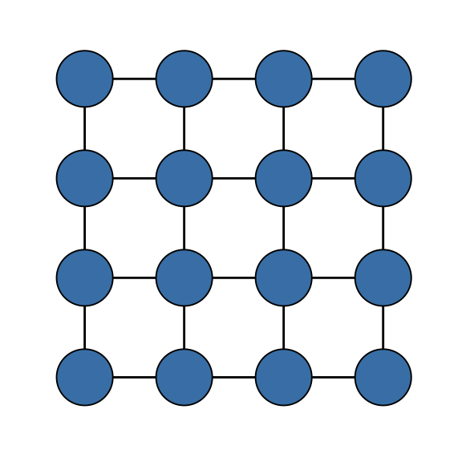

```r
g <- create_lattice(c(4, 4))
plot_lattice <- function(g) {
  p <- ggraph(g, layout = layout_on_grid(g)) +
    geom_edge_link() +
    geom_node_point(size = 12, shape = 21, color = "black", fill = "steelblue") +
    coord_fixed(clip = "off") +
    theme_graph()
  return(p)
}
plot_lattice(g)
```

Consider the following Gibbs step for the Ising model, which is monotonic when $\beta > 0$.

```r
step_local_gibbs <- function(x_n, i, u, beta) {
  n_0 = sum(x_n == 0)
  n_1 = sum(x_n == 1)
  return(as.integer(u < (exp(beta * n_1) / (exp(beta * n_1) + exp(beta * n_0)))))
}
```

Then the following code uses CFTP to generate draws exactly from the Ising model.

```r
cftp_local_gibbs <- function(n = 1, g, beta = 1) {
  steps <- 2^n
  num_nodes <- g %>% activate(nodes) %>% as_tibble() %>% nrow()
  i <- floor(num_nodes * runif(steps)) + 1
  u <- runif(steps)
  x <- rep(0, num_nodes)
  w <- rep(1, num_nodes)
  for (t in 1:steps) {
    neigh <- neighbors(g, i[t])
    x_n <- x[neigh]
    x[i[t]] <- step_local_gibbs(x_n, i[t], u[t], beta)
    w_n <- w[neigh]
    w[i[t]] <- step_local_gibbs(w_n, i[t], u[t], beta)
  }
  if (sum(x) == sum(w) | n > 10) {
    return(x)
  }
  else {
    y <- cftp_local_gibbs(n + 1, g, beta)
    for (t in 1:steps) {
      y_n <- y[neighbors(g, i[t])]
      y[i[t]] <- step_local_gibbs(y_n, i[t], u[t], beta)
    }
    return(y)
  }
}
```

Then the following calculates $h(x)$ for a configuration on a graph.

```r
h <- function(x, g) {
  from <- g %>% activate(edges) %>% pull(from)
  to <- g %>% activate(edges) %>% pull(to)
  return(sum(x[from] == x[to]))
}
```

Using this algorithm to create $10$ iid draws from the Ising model over a 4 by 4 square lattice at $\beta = 1$ and estimate $\mathbb{E}(h(X)).$ Report your estimate as $a \pm b$.

Generate 10 values, estimate the result

```r
set.seed(1234567)
res<-replicate(10, cftp_local_gibbs(n=1, g, beta=1))
stats<-apply(res, MARGIN=2, FUN=h, g=g)

tibble(
  mean=mean(stats),
  se=sd(stats)/sqrt(length(stats))
) %>% kable()
```

| mean | se |
| --- | --- |
| 18.6 | 0.7774603 |

My estimate for $\mathbb{E}(h(X))=\boxed{18.60 \pm 0.78}$.

Continuing the last problem, use your algorithm to run a Markov chain 10 times starting at a stationary state $Y_0$ and using $Y_0, \ldots, Y_{100}$ to estimate $\mathbb{E}(h(X))$ on a 4 by 4 square lattice. Report your estimate as $a \pm b$.

[output not shown]

Write code to draw five points uniformly from $[0, 10]^2$ such that at least one is within distance 1.2 of the point $(2.1, 3.5)$ using Bonferroni AR.

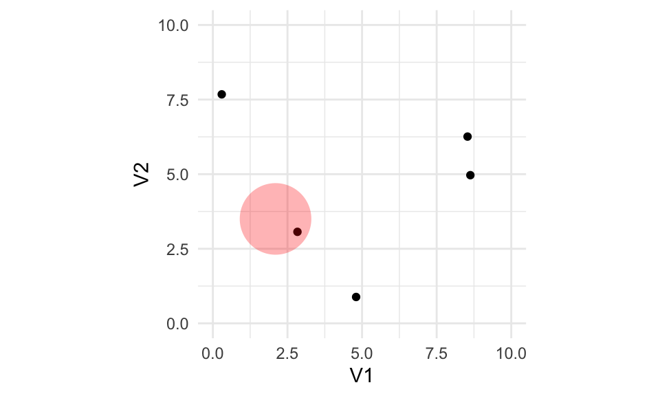

```r
set.seed(1234567)
#ar alg
bonferroni_ar_p5 <- function() {
  a <- FALSE
  while (!a) {
    #choose a point
    i <- floor(5 * runif(1)) + 1

    #determine location of ith point
    r <- sqrt(runif(1.2))
    theta <- 2 * pi * runif(1)
    points <- matrix(rep(0, 10), ncol = 2) # set up points matrix

    for (j in 1:5) {
      if (j == i)
        points[j,] <- c(2.1 + r * cos(theta), 3.5 + r * sin(theta))
      else
        points[j,] <- 10 * runif(2) }

    u <- runif(1)
    # Count how many points are within distance 1 of (3, 5)
    m <- sum(sapply(1:5, function(j) (sqrt(sum((points[j,] - c(2.1, 3.5))^2)) <= 1.2)))
    a <- (u < 1 / m)
  }
return(points)
}

res<-bonferroni_ar_p5() %>% as.data.frame()
ggplot()+geom_point(data=res, aes(x=V1, y=V2))+xlim(c(0,10))+ylim(c(0,10))+coord_fixed()+geom_polygon(data=NULL, aes(x=2.1+1.2*cos(seq(0,2*pi,length=100)), y=3.5+1.2*sin(seq(0,2*pi,length=100))), alpha=0.3, fill="red")+theme_minimal()
```

Bingo! Code is working!

Suppose that each of $B_1, B_2, B_3, B_4$ is equally likely to be 0 or 1. Suppose further that the goal is to sample from the $B_i$ conditioned on event $S$ being true, where
$$S = (B_1 = 1 \vee B_2 = 1 \vee B_3 = 1) \wedge (B_2 = 0 \vee B_3 = 1 \vee B_4 = 0) \wedge (B_1 = 0 \vee B_2 = 0 \vee B_4 = 1).$$

Write basic AR code to sample from this distribution. Use 1000 samples to estimate $\mathbb{P}(B_2 = 1 \mid S).$ Report your result as $a \pm b$.

```r
set.seed(1234567)
basic_ar_p6<-function(){
  s<-FALSE
  while(!s){
    #draw b values
    b<-round(runif(4))
    s=(b[1]==1 | b[2]==1 | b[3]==1) & (b[2]==0 | b[3]==1 | b[4]==1) & (b[1]==0 | b[2]==0 | b[4]==1)
  }
  return(b[2])
}

res<-replicate(1000, basic_ar_p6())

tibble(
  mean=mean(res),
  se=sd(res)/sqrt(length(res))
) %>% kable()
```

| mean | se |
| --- | --- |
| 0.478 | 0.015804 |

My basic AR estimate of $\mathbb{P}(B_2 = 1 \mid S)= \boxed{0.478 \pm 0.016}$.

Consider state space $\Omega = \{\{0, 1\}^4 : S\}.$ Write code that takes an $\textsf{M}\textsf{R}^2\textsf{T}^2$ step where the input is the current state $x$ and $i \in \{1, 2, 3, 4\}$ with $y[-i] = x[-i]$ and $y[i] = 1 - x[i]$.

Note that if proposed move is in $S$, we will **always** accept the proposed move, because the distribution is uniform over $\Omega$. In other words, given they are both in $S$, the proposed state and current state have equal likelihoods, so $U \leq 1$ is always satisfied.

```r
mr2t2_step_p7<-function(x){
  i=floor(4*runif(1))+1
  # do step
  y<-x
  y[i]<-1-x[i]
  #note that the step will always happen
  s=(y[1]==1 | y[2]==1 | y[3]==1) & (y[2]==0 | y[3]==1 | y[4]==1) & (y[1]==0 | y[2]==0 | y[4]==1)
  if(s){
    return(y)
  }
  else{
    return(x)
  }
}
```

This step function returns the current state if the proposed state is not in $S$, and returns the proposed state if it is in $S$.

Consider two circles that overlap. Circle $A$ has area $(1/2)\tau \cdot 1.1^2$. Circle $B$ has area $(1 / 2)\tau 1.4^2$. There is a rectangle $R$ of area 16 that contains both circles. Let $X \sim \textsf{Unif}(R)$.

1. What is $\mathbb{P}(X \in A)$?
2. What is $\mathbb{P}(X \in B)$?
1. $\mathbb{P}(X \in A) = \frac{m(A)}{m(R)}=\frac{(1/2)\tau \cdot 1.1^2}{16}= \boxed{0.238}$
2. $\mathbb{P}(X \in B) = \frac{m(B)}{m(R)}=\frac{(1/2)\tau \cdot 1.4^2}{16}= \boxed{0.385}$

Suppose the following code can be used to determine if a point is in $A$ or $B$, and to draw from the areas of circles $A$ and $B$.

```r
is_in_A <- function(x) return(sum((x - c(1.5, 1.2))^2) <= 1.1^2)
is_in_B <- function(x) return(sum((x - c(2.6, 1.8))^2) <= 1.4^2)
rA <- function() {
  theta <- 2 * pi * runif(1)
  r <- 1.1 * sqrt(runif(1))
  return(c(1.5 + r * cos(theta), 1.2 + r * sin(theta)))
}
rB <- function() {
  theta <- 2 * pi * runif(1)
  r <- 1.4 * sqrt(runif(1))
  return(c(2.6 + r*cos(theta), 1.8 + r*sin(theta)))
}
```

1. Write Bonferroni AR code using these functions to draw uniformly from $A \cup B$.
2. Use your code to estimate the area of $A \cap B$ divided by the area of $A \cup B$ using 1000 samples. Report your result as $a \pm b$.

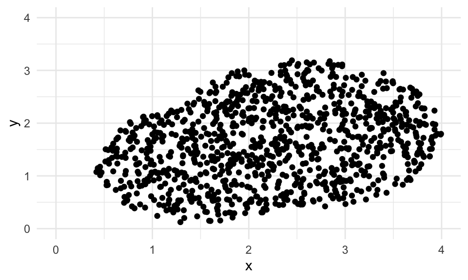

```r
set.seed(1234567)

bonf_ar_p9<-function(){
  a<-FALSE
  while(!a){
    #draw an index according to the probabilities of
    i<-sample(x=c(1,2,3), size=1, prob=c(pi*1.1^2 * 1/16, pi*1.4^2 * 1/16, 1-(pi*1.1^2 * 1/16 + pi*1.4^2 * 1/16)))
    u<-runif(1)
    if(i==1){
      x<-rA()
      #we don't want to count the intersection twice, so we only
      #pass the TRUE flag our uniform is less than the number of conditions passed
      a<-(u <= 1/(is_in_A(x)+is_in_B(x)))
    }
    if(i==2){
      x<-rB()
      a<-(u <= 1/(is_in_A(x)+is_in_B(x)))
    }
    #if neither condition is selected, just run basic ar
    if(i==3){
      x<-runif(2)*4
      a<-(is_in_A(x)|is_in_B(x))
    }
  }
  return(x)
}

replicate(1000, bonf_ar_p9()) %>% t() %>% as.data.frame() %>% ggplot(aes(x=V1, y=V2))+geom_point()+xlim(c(0,4))+ylim(c(0,4))+xlab("x")+ylab("y")+theme_minimal()
```

Looks like my code is working!

```r
set.seed(1234567)
points<-replicate(1000, bonf_ar_p9()) %>% t()
res<-cbind(points %>% apply(MARGIN=1, FUN=is_in_A), points %>% apply(MARGIN=1, FUN=is_in_B)) %>% rowSums()==2
tibble(
  mean=mean(res),
  se=sd(res)/sqrt(length(res))
)
```

```
## # A tibble: 1 x 2
##    mean     se
##   <dbl>  <dbl>
## 1 0.246 0.0136
```

My proportion of total draws that lies in $A \cap B$ (i.e., $\frac{m(A \cap B)}{m(A \cup B)}$) is $\boxed{0.246 \pm 0.014}$.

Consider the following probabilistic recursive algorithm for generating a geometric random variable with parameter $p$.

```r
rgeo_onedraw <- function(p) {
  u <- runif(1)
  if (u < p)
    return(1)
  else
    return(1 + rgeo_onedraw(p))
}
```

Show that this algorithm is locally correct for output $G$ such that $\mathbb{P}(G = i) = (1 - p)^{i - 1} p \mathbb{I}(i \in \{1, 2, 3, \ldots\})$.

Suppose $G$ is output the`rgeo_onedraw` algorithm. Let $Y$ be the output of the recursive call. We know $\mathbb{P}(Y = i) = (1 - p)^{i - 1} p$. Prove original.

Let $G$ be the output of the call to the algorithm. For any $i$:
$$P(G=i)=P(G=X, X=i)+P(G=Y, Y=i)$$
$$P(G=i)=P(G=X | X=i) \cdot P(X=i) +P(G=Y | Y=i) \cdot P(Y=i)$$
$$P(G=i)= p \cdot P(X=i) + (1-p) \cdot P(Y=i)$$
$$P(G=i) - p \cdot P(X=i) = (1-p) \cdot P(Y=i)$$
Assuming that $P(G=i)$ and $P(X=i)$ are the same, because they are both based on the `rgeo_onedraw` algorithm:
$$(1-p) \cdot P(G=i) = (1-p) \cdot P(Y=i)$$
$$P(G=i) = P(Y=i) = (1 - p)^{i - 1} p$$
Because we supposed that $Y$ was an oracle. In short, we assumed the recursive call was true and used it to prove that the original algorithm was locally correct.